# ResNet50 CNN model

The learning curves of the training and validation accuracy/loss when using the ResNet50 base model as a fixed feature extractor.

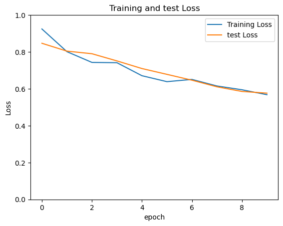

```python
train_loss = history.history['loss']
val_loss = history.history['val_loss']

plt.plot(train_loss, label='Training Loss')
plt.plot(val_loss, label='test Loss')
plt.legend(loc='upper right')
plt.ylabel('Loss')
plt.ylim([0,1.0])
plt.title('Training and test Loss')
plt.xlabel('epoch')
plt.show()
```

We knew that the symptoms of under-fitted is high training error, training error close to test error and high bias. So from above figure, we can see that the basic model is under-fitted.

```python
loss_eval, accuracy = model.evaluate(test_dataset)
print('Test accuracy :', accuracy)
```

```
Test accuracy : 0.8500000238418579
```

Train the model using weight fine-tuning

One way to increase performance even further is to train (or "fine-tune") the weights of the top layers of the pre-trained model alongside the training of the classifier we added. The training process will force the weights to be tuned from generic feature maps to features associated specifically with the dataset.

In most convolutional networks, the higher up a layer is, the more specialized it is. The first few layers learn very simple and generic features that generalize to almost all types of images. As go higher up, the features are increasingly more specific to the dataset on which the model was trained. The goal of fine-tuning is to adapt these specialized features to work with the new dataset, rather than overwrite the generic learning.

```python
#unfreeze the base_model
base_model.trainable = True

# take a look to see how many layers are in the base model
print("Number of layers in the base model: ", len(base_model.layers))
```

```
Number of layers in the base model:  175
```

Compile the model

Training a much larger model and want to readapt the pretrained weights, it is important to use a lower learning rate at this stage. Otherwise, the model could overfit very quickly.

```python
# Fine-tune from this layer onwards
fine_tune_at = 100

# Freeze all the layers before the `fine_tune_at` layer
for layer in base_model.layers[:fine_tune_at]:
  layer.trainable = False

#compile the model,Since there are two classes, use the tf.keras.losses.BinaryCrossentropy loss with from_logits=True since the model provides a linear output.
model.compile(loss=keras.losses.BinaryCrossentropy(from_logits=True),
              optimizer = keras.optimizers.RMSprop(learning_rate=base_learning_rate/10),
              metrics=['accuracy'])
model.summary()
```

```
Model: "model"
_________________________________________________________________
 Layer (type)                Output Shape              Param #
=================================================================
 input_2 (InputLayer)        [(None, 160, 160, 3)]     0

 sequential (Sequential)     (None, 160, 160, 3)       0

 tf.__operators__.getitem (S  (None, 160, 160, 3)      0
 licingOpLambda)

 tf.nn.bias_add (TFOpLambda)  (None, 160, 160, 3)      0

 resnet50 (Functional)       (None, 5, 5, 2048)        23587712

 global_average_pooling2d (G  (None, 2048)             0
 lobalAveragePooling2D)

 dropout (Dropout)           (None, 2048)              0

 dense (Dense)               (None, 1)                 2049

=================================================================
Total params: 23,589,761
Trainable params: 19,454,977
Non-trainable params: 4,134,784
_________________________________________________________________
```

```python
len(model.trainable_variables)
```

```
92
```

Continue training the model

```python
fine_tune_epochs = 10
total_epochs =  initial_epochs + fine_tune_epochs
#continue training the model
history_fine = model.fit(train_dataset,
                         epochs=total_epochs,
                         initial_epoch=history.epoch[-1],
                         validation_data=test_dataset)
```

[output not shown]

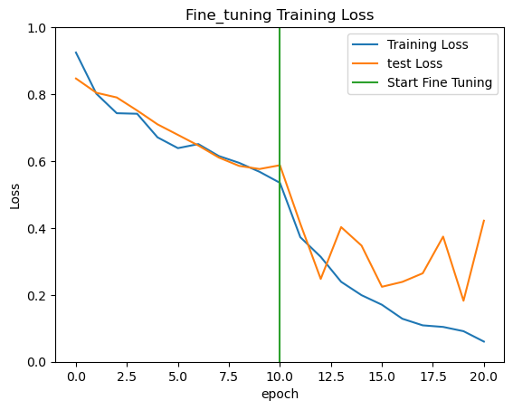

```python
train_loss += history_fine.history['loss']
val_loss += history_fine.history['val_loss']

plt.plot(train_loss, label='Training Loss')
plt.plot(val_loss, label='test Loss')
plt.ylim([0, 1.0])
plt.plot([initial_epochs,initial_epochs],
         plt.ylim(), label='Start Fine Tuning')
plt.legend(loc='upper right')
plt.title('Fine_tuning Training Loss')
plt.xlabel('epoch')
plt.ylabel('Loss')
plt.show()
```

Evaluation and prediction

```python
loss, accuracy = model.evaluate(test_dataset)
print('Test accuracy :', accuracy)
```

```
Test accuracy : 0.875
```

```
Predictions:
 [1 1 0 1 0 1 1 0 0 1 1 0 1 1 1 0 1 1 1 1 0 1 1 0 1 1 1 0 1 1 0 1]
Labels:
 [0 0 0 1 0 1 1 0 0 1 1 0 1 0 1 0 0 1 0 1 0 1 1 0 1 1 1 0 0 1 0 1]
```

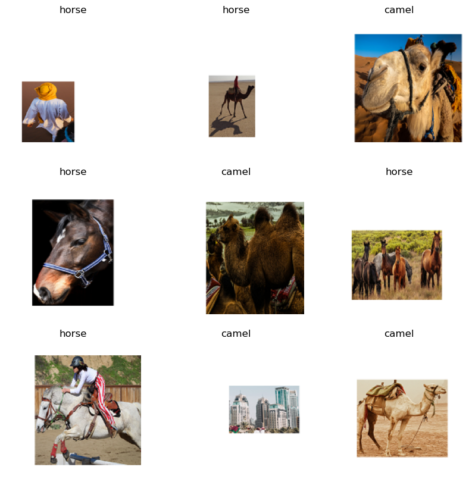

```python
# Retrieve a batch of images from the test set
image_batch, label_batch = test_dataset.as_numpy_iterator().next()
predictions = model.predict_on_batch(image_batch).flatten()

# Apply a sigmoid since our model returns logits
predictions = tf.nn.sigmoid(predictions)
predictions = tf.where(predictions < 0.5, 0, 1)

print('Predictions:\n', predictions.numpy())
print('Labels:\n', label_batch)

plt.figure(figsize=(10, 10))
for i in range(9):
  ax = plt.subplot(3, 3, i + 1)
  plt.imshow(image_batch[i].astype("uint8"))
  plt.title(class_names[predictions[i]])
  plt.axis("off")
```

Confusion Matrix

```
[[10  6]
 [ 0 16]]
```

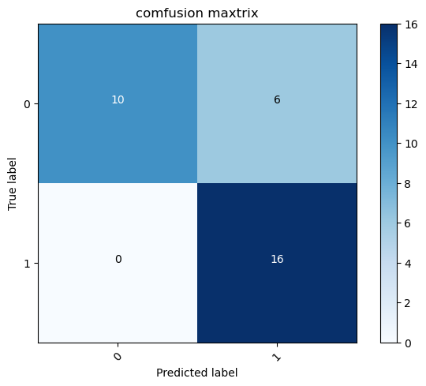

```python
#Compute confusion matrix to evaluate the accuracy of a classification.
cm = confusion_matrix(y_true=label_batch, y_pred=predictions,labels=[0,1])
print(cm)
classes = ['0','1']
plt.imshow(cm, interpolation='nearest', cmap=plt.cm.Blues)
plt.title('comfusion maxtrix')
plt.colorbar()
tick_marks = np.arange(len(classes))
plt.xticks(tick_marks, classes, rotation=45)
plt.yticks(tick_marks, classes)

thresh = cm.max() / 2.
for i, j in itertools.product(range(cm.shape[0]), range(cm.shape[1])):
    plt.text(j, i, cm[i, j],
    horizontalalignment="center",
    color="white" if cm[i, j] > thresh else "black")

plt.tight_layout()
plt.ylabel('True label')
plt.xlabel('Predicted label')
plt.savefig('./confusion_matrix.jpg')
```

```python
#for camels
TP = cm[0][0]
FN = cm[0][1]
FP = cm[1][0]
TN = cm[1][1]
accuracy_camel = (TP+TN)/(TP+FN+FP+TN)
precision_camel = TP/(TP+FP)
sensitivity_camel = TP/(TP+FN)
specificity_camel = TN/(TN+FP)
print("For camels: accuracy = ", accuracy_camel," precision = ",precision_camel, " sensitivity = ",sensitivity_camel, " specificity = ", specificity_camel)

#for horses
accuracy_horse = (TN+TP)/(TP+FN+FP+TN)
precision_horse = TN/(TN+FN)
sensitivity_horse = TN/(TN+FP)
specificity_horse = TP/(TP+FN)
print("For horses: accuracy = ", accuracy_horse," precision = ",precision_horse, " sensitivity = ",sensitivity_horse, " specificity = ", specificity_horse)
```

```
For camels: accuracy =  0.8125  precision =  1.0  sensitivity =  0.625  specificity =  1.0
For horses: accuracy =  0.8125  precision =  0.7272727272727273  sensitivity =  1.0  specificity =  0.625
```

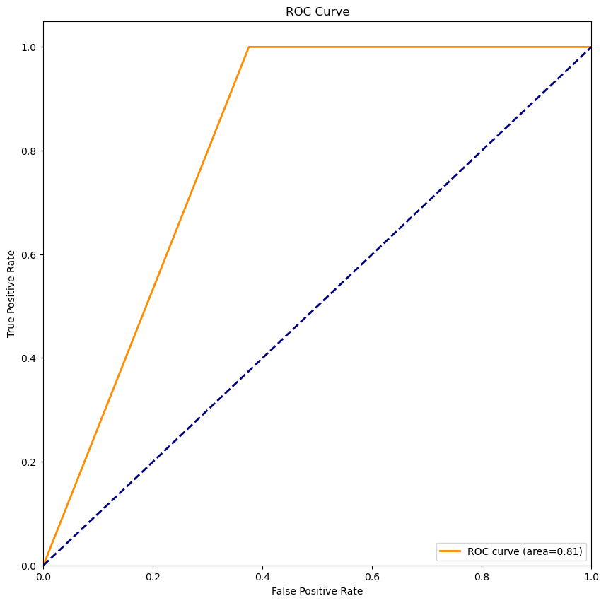

```python
#plot the ROC
fpr,tpr,threshold = roc_curve(label_batch,predictions)
roc_auc = auc(fpr,tpr)
plt.figure()
lw=2
plt.figure(figsize=(10,10))
plt.plot(fpr,tpr,color='darkorange',lw=lw,label='ROC curve (area=%0.2f)'%roc_auc)
plt.plot([0,1],[0,1],color='navy',lw=lw,linestyle='--')
plt.xlim([0.0,1.0])
plt.ylim([0.0,1.05])
plt.xlabel('False Positive Rate')
plt.ylabel('True Positive Rate')
plt.title('ROC Curve')
plt.legend(loc='lower right')
plt.show()
```

Summary

In this assignment, to get the training model, only changed the top-level layers of the pre-trained models via fine-tuning, the layers below the top-levl were kept. The accuracy of the training model with fine tuning is better than the pre-trained models, so the trainning model with fine tuning could get better result.